# ANLY601 Assignment1

Xiner Ning

1/20/2020

# Problem

## Exercise 1 (Likelihood Estimation)

1. What is the maximum likelihood estimate for $\theta$ when $X_i$ ~ Geometric($\theta$)?

PMF for Geometric Distribution is $f(x) = \theta(1-\theta)^{x-1}$

Log Likelihood function for $\theta$ is:

$l(\theta) = \Pi_{i=1}^{n}ln[(1-\theta)^{x_i-1}\theta]$

=$\Sigma_{i=1}^{n}ln[(1-\theta)^{x_i-1}\theta]$ = $\Sigma_{i=1}^{n}[ln(1-\theta)^{x_i-1}+ln\theta]$

= $\Sigma_{i=1}^{n}ln\theta + \Sigma_{i=1}^{n}(x_1-1)ln(1-\theta)$

MLE for $\theta$ is the $\theta$ such that $\frac{\partial}{\partial\theta}{\{\Sigma_{i=1}^{n}ln\theta + \Sigma_{i=1}^{n}(x_1-1)ln(1-\theta)}\} = 0$,

so $\frac{n}{\theta} + \Sigma_{i=1}^{n}(x_1-1)\frac{-1}{1-\theta}$,

so $\frac{n}{\theta} - \frac{1}{1-\theta}\Sigma_{i=1}^{n}x_i + \frac{n}{1-\theta} = 0$,

so $\frac{n}{\theta(1-\theta)} = \frac{1}{1-\theta}\Sigma_{i=1}^{n}x_i$,

so $\hat{\theta} = \frac{n}{\Sigma_{i=1}^{n}x_i}$

2. What is the maximum likelohood estimate for a and b when $X_i$ ~ $Unif(a,b)$?

PDF for Uniform Distribution is $f(x;a,b) = \frac{1}{b-a}$

So the Likelihood function is $\Pi_{i=1}^{n}f(x_i;a,b) = \frac{1}{(b-a)^n}$

Take log on both sides of the function

$log\Pi_{i=1}^{n}f(x_i;a,b) = -nlog(b-a)$

Take derivative of the function on a, we get

$\frac{\partial}{\partial a} = \frac{n}{b-a}$, which is monotonically increasing. Thus, the MLE for a would be the largest a possible, which would simply be:

$\hat{a} = \min{x_1,x_2,...x_n}$

Take derivative of the function on b, we get

$\frac{\partial}{\partial b} = \frac{-n}{b-a}$, which is monotonically decreasing. Thus, the MLE for b would be the smallest b possible, which would simply be:

$\hat{b} = \max{x_1,x_2,...x_n}$

## Exercise 2 (Loss Function)

1. Show that squarred error loss (L2 loss) is equivalent to the negative log likelihood of a $Y$ ~ $N(\mu,\sigma^2)$ where $\sigma$ is known.

$P(y|\mu,\sigma) = \frac{1}{\sqrt{2\pi\sigma^2}}e^\frac{-(y-\mu)^2}{2\sigma^2}$

Likelihood Function $L(\mu,\sigma^2 | y_1,y_2,...y_n) = (2\pi\sigma^2)^\frac{-n}{2}exp(\frac{-1}{2\sigma^2}\Sigma_{i=1}^{n}(y_i-\mu)^2)$

So Log Likelihood Function $l = \frac{-n}{2}ln(2\pi\sigma^2) - \frac{1}{2\sigma^2}\Sigma_{i=1}^{n}(y_i-\mu)^2)$

So Negative Log Likelihood Function is $-l = \frac{n}{2}ln(2\pi\sigma^2) + \frac{1}{2\sigma^2}\Sigma_{i=1}^{n}(y_i-\mu)^2)$, where n and $\sigma$ are constant.

Since L2 Loss Function is $\Sigma_{i=1}^{n}(y_y-y_{predicted})^2$, the two functions are equivalent.

2. Show that the mean absolute error (L1 loss) is equivalent to the nagative log likelihood of a $Y$ ~ $LaPlace(\theta)$.

$f_y(y)=\frac{1}{2}e^{|y-\theta|}$

Likelihood Function $L(\theta | y_1,y_2,...y_n) = 2^{-n}exp(\Sigma_{i=1}^{n}-|y_i-\theta|)$

So Log Likelihood Function $l=-nln2 - \Sigma_{i=1}^{n}|y_i-\theta|$

So Negative Log Likelihood Function $-l=nln2 + \Sigma_{i=1}^{n}|y_i-\theta|$, where n is constant.

Since L1 Loss Function is $\Sigma_{i=1}^{n}|y_y-y_{predicted}|$ , the two functions are equivalent.

## Exercise 3 (Decision Rules)

1. Risk function $R = E_\mu[\space L(\mu,\delta(x))\space] = E_\mu[\space (\delta(x)-\mu\space)^2]$

$= E[\delta^2(x)]-2\mu E[\delta(x)] + \mu^2 = E[\delta^2(x)]-2\mu^2 + \mu^2$, since $\delta(x)$ is unbaised so $E[\delta(x)]=\mu$

When $\delta(x) = \bar{x}$, $E[\delta^2(x)]-2\mu^2 + \mu^2$ is minimized since $E[\delta^2(x)]-2\mu^2 + \mu^2 = E[\mu^2]-\mu^2 = 0$

So $\bar{x}$ is the optimal decision rule for the mean squarred error.

2. Risk function $R = E_\mu[\space L(\mu,\delta(x))\space] = E_\mu[\space |\delta(x)-\mu\space|]$

So R is nothing but mean deviation about $\mu$. Since mean deviation is minimized when the estimator is median, median is the optimal decision rule for the absolite loss error.

## Exercise 4 (Convexity)

1. $L(y,p) = -(ylog(\frac{1}{1+e^{-\beta x}})+(1-y) log(1-\frac{1}{1+e^{-\theta x]}}))$

$=-(ylog(e^{\beta x}) -y log(1+e^{\beta x}) + log(\frac{1}{1+e^{\beta x} })+ ylog(1+e^{\beta x}))$

$= -(ylog(e^{\beta x})- log(1+e^{\beta x}))$

$= -xy\beta + log(1+e^{\beta x})$

Here we use the second derivative rule to prove convexity.

$\frac{\partial L}{\partial \beta} = -xy+\frac{e^{\beta x}x}{1+e^{\beta x}} = -xy + \frac{x}{1+e^{-\beta x}}$

$\frac{\partial L}{\partial \beta^2} = \frac{x^2e^{-\beta x}}{(1+e^{-\beta x})^2}$, which is $\geq 0$

Thus, the function L is convex.

2. Same as above, we use the second derivative rule to prove convexity.

$\frac{\partial L}{\partial \beta} = (2xy+2xye^{-\beta x}-2x)(1+e^{-\beta x})^{-3}$

$\frac{\partial L}{\partial \beta^2} = \frac{(e^{-\beta x})(-2x^2y-2x^2ye^{\beta x} -6xy)-6xy}{(1+e^{-\beta x})^4}$

Since there is no sign showing that the second derivative is $\geq0$, the function is not convex in $\beta$.

## Exercise 5(Decision Boundaries)

Plot 3 different $f_\beta(x)$ with 3 sets of $\beta$ values:

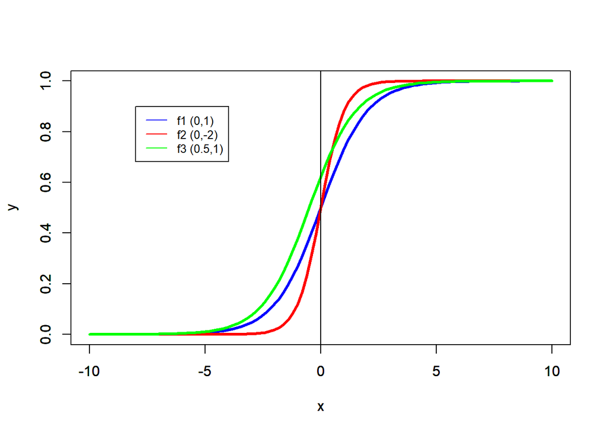

```r
eq1 = function(x){1/(1+exp(-x))}
eq2 = function(x){1/(1+exp(-2*x))}
eq3 = function(x){1/(1+exp(-0.5-x))}

plot(eq1, from=-10, to=10, xlab="x", ylab="y",col='blue',lwd=3)
par(new=TRUE)
plot(eq2, from=-10, to=10, xlab="x", ylab="y",col='red',lwd=3)
par(new=TRUE)
plot(eq3, from=-10, to=10, xlab="x", ylab="y",col='green',lwd=3)


legend(-8, 0.9, legend=c("f1 (0,1)", "f2 (0,-2)",'f3 (0.5,1)'),
       col=c("blue", "red",'green'), lty=1, cex=0.8)

abline(v=0, col="black")
```

logit$f_(x) = $ logit($\frac{1}{1+e^{-\beta x}}$) = $ln( \frac{\frac{1}{1+e^{-\beta x}}}{1-\frac{1}{1+e^{-\beta x}}} ) = \beta_0 + \beta_1x$

Since the decision threshold is about $f_\beta(0)$, based on the graph above:

when the dataset is balanced -> f1 and f2 are better models than f3

when the dataset is skewed towards to Class A -> f1 and f2 are better models than f3

when the data is skewed towards to Class B -> f3 is better model than f1 and f2

So $\beta_0 + \beta_1x$ is a linear separating hyperplane.

## Exercise 6 (Sufficient Statistics)

$f_n(x|\mu) =\Pi_{i=1}^{n}(\frac{1}{\sigma \sqrt{2\pi}})^nexp(\frac{-(x_i-\mu)^2}{2\sigma^2})$

$= (\frac{1}{\sigma \sqrt{2\pi}})^n exp(\frac{-\Sigma(x_i^2-2x_i\mu+\mu^2)}{2\sigma^2})$

$= (\frac{1}{\sigma \sqrt{2\pi}})^n exp(-\Sigma x_i^2)exp(2n\mu \bar{x}-n\mu^2)$

Since the first two terms do not depend on $\mu$, and the last term depend on $\mu$ only through $\bar{x}$. By factorization theorem, $T=\bar{x}$ is a sufficient statistics for $\mu$.

## Exercise 7 (Ancilliarity) Q1

$F_R(r|\theta) = P_\theta(R\leq r)$ $=P_\theta(max_i(x_i) - min_i(x_i) \leq r)$  
$= P_\theta(max_i(z_i+\theta) - min_i(z_i-\theta))$  
$= P_\theta(max_iz_i-min_iz_i) \leq r$, which is not depend on $\theta$ because the distribution of $z_1,z_2,...,z_n$ does not depende on $\theta$.

## Exercise 8 (Completeness)

Suppose X follows distribution $N ~ (\mu,\mu^2)$

$f(x|\mu) = (\frac{1}{\mu \sqrt{2\pi}})^n e^{\frac{-\Sigma(x_i-\mu)^2}{2\mu^2}}$

$= (\frac{1}{ \sqrt{2\pi}})^n e^{\frac{-n}{2}} (\frac{1}{\mu})^n e^{\frac{-\Sigma x_i^2}{2\mu^2}} e^{\frac{n\Sigma x_i}{\mu}}$

By Factorization Theorem, the sufficient statistics for $\mu$ is $T(x) = (\Sigma x_i^2,\Sigma x_i)$

Let $g(T) = n \Sigma x_i^2 - 2(\Sigma x_i)^2$,

so $E_\mu(g(T)) = nE(x_i^2 + ... + x_n^2) - 2E(\Sigma x_i)E(\Sigma x_i)$

Since $E(\Sigma x_i) = E(n\bar{x}) = n\mu$

$E_\mu(g(T)) = nE(x_i^2)+...+nE(x_n^2)-2(n\mu)^2$

Since $E(x_i^2) = \sigma^2 + \mu^2 = 2\mu^2$

$E_\mu(g(T)) = 2n^2\mu^2-2n^2\mu^2 =0$

Since $P_\mu (n \Sigma x_i^2 - 2(\Sigma x_i)^2=0) = P_\mu(n \Sigma x_i^2 = 2(\Sigma x_i)^2) \neq 1$ for all $\mu$, by the definition of Complete Statistics, $T(x) = (\Sigma x_i^2,\Sigma x_i)$ is not complete.

## Exercise 9 (Regular exponential family)

1. $P(x|\theta) = \frac{\theta^x e^{-\theta}}{x!} = \frac{1}{x!}exp(log_{\theta}{x}-\theta)$

So Poission Distribution is part of the regular exponential family with

$h(x) = \frac{1}{x!}$, $\eta(\theta) = log(\theta)$, $T(x) = x$, $B(\theta) = \theta$

## Exercise 10 (Regular Exponential Family)

The regular exponential family has form:

$f(X=x | \eta) = h(x)exp(\space \eta T(x)-B(\eta)\space ), h(x)>0$

Then  
$E_\eta[\space T(x) \space] = B'(\eta)$  
$Var[\space T(x) \space] = B''(\eta)$

So  
$Cov(T_i(x),T_j(x)) = E[\space T_i(x)T_j(x) \space] - E[T_i(x)]E[T_j(x)]$

$= E[T^{2}(x)] - E^2[T(x)]$

$= Var[T(x)] + E^2[T(x)] - E^2[T(x)] = Var[T(x)] = B''(\eta) = \frac{\partial B(\eta)}{\partial\eta_i \partial\eta_j}$

So the equation is proved.

## Exercise 11 (Delta Method)

Suppose X follows Bernoulli Distribution with $\mu$ and $\sigma^2$.

By Central Limit Theorem, $\bar{X}$ ~ N($\mu$,$(\frac{\sigma}{\sqrt{n}})^2$)

So for random variable $\sqrt{n}(\bar{x}-\mu)$, $E[\sqrt{n}(\bar{x}-\mu)]= 0$, $Var[\sqrt{n}(\bar{x}-\mu)]= Var[\sqrt{n}\bar{x}]=nVar[\bar{x}]=\sigma ^2$

So we have $\sqrt{n}(\bar{x}-\mu)$ ~ N(0,$\sigma^2$)

Let function $g(x)=x(1-x)$, so $g(\bar{x}) = \bar{x}(1-\bar{x})$, $g(\mu) = \mu(1-\mu)$, so $g'(\mu) = 1-2\mu$

Based on Delta Method, $\sqrt{n}[\bar{x}(1-\bar{x})-\mu(1-\mu)]$ ~ $N(0,\sigma^2(1-2\mu)^2)$

Adding constant $\sqrt{n}\mu(1-\mu)$ to the random variable will not change the variance and will increase the mean by $\sqrt{n}\mu(1-\mu)$.

So $\sqrt{n}\bar{x}(1-\bar{x})$ ~ $N(\sqrt{n}\mu(1-\mu),\sigma^2(1-2\mu)^2)$

Multiply the random variable by $\frac{1}{\sqrt{n}}$, now we have

$\bar{x}({1-\bar{x}})$ ~ $N(\mu(1-\mu),\frac{\sigma^2(1-2\mu)^2}{n})$

Since X ~ Bernoulli ($\mu$,$\sigma^2$) with probability p, we know $\mu$ = p and $\sigma^2$=p(1-p)

Replace $\mu$ and $\sigma$, we get:

$\hat{\tau}= \hat{p}(1-\hat{p})= \bar{x}(1-\bar{x})$ ~ $N(p(1-p),\frac{p(1-p)(1-2p)^2}n)$

## Exercise 12 (Differential Entropy)

Differential Entropy of a continuous random variable X is $h(X) = -\int_{-\infty}^{\infty}f(x)logf(x) dx$

Here $f(x) = N(x; \mu,\Sigma) = \frac{1}{(2\pi)^{\frac{d}{2}}\sqrt{|\Sigma|}} exp(-\frac{1}{2}(x-\mu)\Sigma^{-1}(x-\mu)^T)$, where $x$,$\mu$ are d-dimension vectors. $|\Sigma|$ is the determinant of covariance matrix.

Thus, $h(x) = -\int_{-\infty}^{\infty} N(x;\mu,\Sigma)ln(N(x;\mu,\Sigma)) dx$

$= E[ln(N(x;\mu,\Sigma))]$

$=-E[ln([(2\pi)^d|\Sigma|]^{-\frac{1}{2}})+ln e^{-\frac{1}{2}(x-\mu)^{T}\Sigma^{-1}(x-\mu)}$

$= -E[ln([(2\pi)^{d}|\Sigma|]^{\frac{1}{2}})] - E[lnexp(-\frac{1}{2}(x-\mu)^{T}\Sigma^{-1}(x-\mu))]$

$= -E[-\frac{1}{2}ln((2\pi)^d|\Sigma|))] + \frac{1}{2}E[(x-\mu)^{T}\Sigma^{-1}(x-\mu)]$

$= \frac{d}{2}ln(2\pi)+\frac{1}{2}ln(|\Sigma|) + \frac{1}{2}E[(x-\mu)^{T}\Sigma^{-1}(x-\mu)]$

By the property of trace, $\frac{1}{2}E[(x-\mu)^{T}\Sigma^{-1}(x-\mu)] = \frac{1}{2}E[trace((x-\mu)^{T}\Sigma^{-1}(x-\mu))]$

$=\frac{1}{2}trace(\Sigma^{-1}E[(x-\mu)(x-\mu)^T])$

$= \frac{1}{2}trace(I) = \frac{d}{2}$

So $h(x) = \frac{d}{2}ln(2\pi)+\frac{1}{2}ln(|\Sigma|) + \frac{d}{2}$

## Exercise 13 (Joint Entropy)

1. Joint entropy
   $$\begin{align*}
   H(x,y) &= -\sum_{X,Y} p(X,Y) \log p(X,Y)\\
   &= -\frac{1}{4}\log \frac{1}{4} - \frac{1}{12} \log \frac{1}{12} - \frac{1}{6} \log \frac{1}{6} - \frac{1}{12} \log \frac{1}{12} - \frac{1}{4}\log \frac{1}{4} - \frac{1}{6} \log \frac{1}{6}\\
   &= \frac{5}{3} + \frac{1}{2}\log 3
   \end{align*}$$
2. The marginal of x: $p(x=0)=\frac{1}{3}$, $p(x=1)=\frac{1}{3}$, $p(x=2)=\frac{1}{3}$

p(Y|X):  
$p(y=0|x=0)=\frac{3}{4}$, $p(y=0|x=1)=\frac{1}{4}$,  
$p(y=0|x=2)=\frac{1}{2}$, $p(y=1|x=0)=\frac{1}{4}$,  
$p(y=1|x=1)=\frac{3}{4}$, $p(y=1|x=2)=\frac{1}{2}$

So $H(Y|X) = -\Sigma_{x} p(x) \Sigma_{y}p(y|x)\space log\space p(y|x) = \frac{5}{3}-\frac{1}{2}log3$

3. $H(X) = -\Sigma p(x)log \space p(x) = -\frac{1}{3}log(\frac{1}{3})*3 = log3$

So $H(X) + H(Y|X) = \frac{5}{3} + \frac{1}{2}\log 3 = H(X,Y)$, the entropy results are consistent with the chain rule $H(X,Y) = H(X) + H(Y|X)$

## Huffman coding and probability trees

Step 1: sort words in the ascending order of their frequency/probability

dog 1  
paper 1  
cat 2  
shelf 3  
geometric 3  
vase 4  
runner 6

Step 2: start creating the code tree by combining the two words with the least frequency into a single node

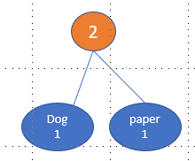

Step 3: keep adding the word with the next largest probability to the tree until there is no word with probability larger than the sum.

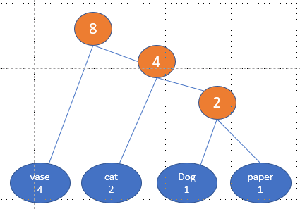

Step 4: now we start a new tree with the same process

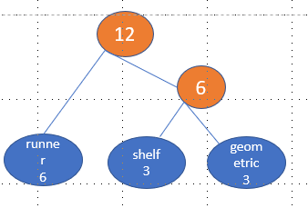

Step 5: now we combine the two trees together

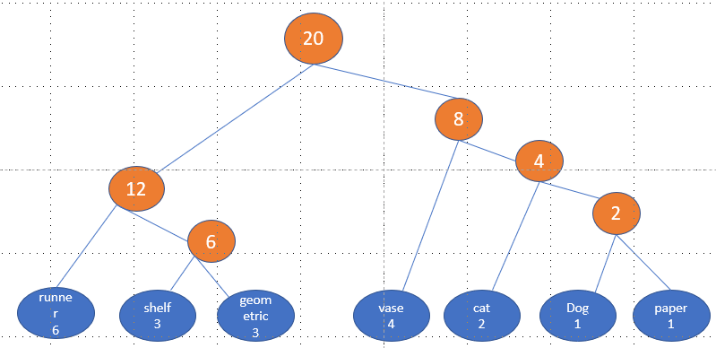

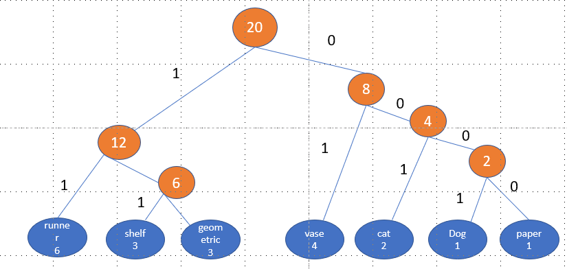

The total bits is $\Sigma$(length of encoding)(frenquency) = 52

The average bit is $\frac{52}{20}=2.6$